# Getting started with ggseg

If you work with neuroimaging data, you’ve probably spent time wrestling region-level results into brain plots. ggseg handles that plumbing for you. It stores brain atlas geometries and plots them as ggplot2 layers, so you get brain figures with the same code you’d use for any other ggplot.

```r
library(ggseg)
library(ggplot2)
```

## What’s in a brain atlas

A `brain_atlas` object bundles four things: a name, a type (cortical, subcortical, or tract), region geometry, and an optional colour palette.

```r
dk()
```

```
#>
#> ── dk ggseg atlas ──────────────────────────────────────────────────────────────
#> Type: cortical
#> Regions: 35
#> Hemispheres: left, right
#> Views: inferior, lateral, superior, medial
#> Palette: ✔
#> Rendering: ✔ ggseg
#> ✔ ggseg3d (vertices)
#> ────────────────────────────────────────────────────────────────────────────────
#>    hemi                            region                      label
#> 1  left banks of superior temporal sulcus                lh_bankssts
#> 2  left         caudal anterior cingulate lh_caudalanteriorcingulate
#> 3  left             caudal middle frontal     lh_caudalmiddlefrontal
#> 4  left                   corpus callosum          lh_corpuscallosum
#> 5  left                            cuneus                  lh_cuneus
#> 6  left                        entorhinal              lh_entorhinal
#> 7  left                          fusiform                lh_fusiform
#> 8  left                 inferior parietal        lh_inferiorparietal
#> 9  left                 inferior temporal        lh_inferiortemporal
#> 10 left                 isthmus cingulate        lh_isthmuscingulate
#>            lobe
#> 1      temporal
#> 2     cingulate
#> 3       frontal
#> 4  white matter
#> 5     occipital
#> 6      temporal
#> 7      temporal
#> 8      parietal
#> 9      temporal
#> 10    cingulate
#> ... with 60 more rows
```

The `dk` atlas (Desikan-Killiany) ships with the package. Call `plot()` for a quick look:

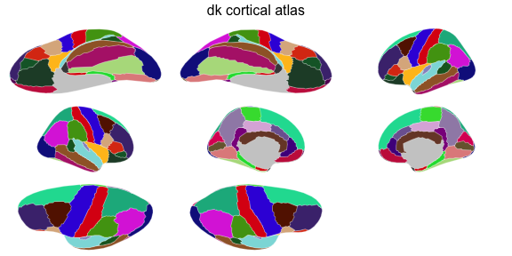

Quick overview of the Desikan-Killiany cortical atlas.

```r
plot(dk())
```

Two helpers pull out the names you’ll need for matching data:

```r
library(ggseg.formats)

atlas_regions(dk())
```

```
#>  [1] "banks of superior temporal sulcus" "caudal anterior cingulate"
#>  [3] "caudal middle frontal"             "corpus callosum"
#>  [5] "cuneus"                            "entorhinal"
#>  [7] "frontal pole"                      "fusiform"
#>  [9] "inferior parietal"                 "inferior temporal"
#> [11] "insula"                            "isthmus cingulate"
#> [13] "lateral occipital"                 "lateral orbitofrontal"
#> [15] "lingual"                           "medial orbitofrontal"
#> [17] "middle temporal"                   "paracentral"
#> [19] "parahippocampal"                   "pars opercularis"
#> [21] "pars orbitalis"                    "pars triangularis"
#> [23] "pericalcarine"                     "postcentral"
#> [25] "posterior cingulate"               "precentral"
#> [27] "precuneus"                         "rostral anterior cingulate"
#> [29] "rostral middle frontal"            "superior frontal"
#> [31] "superior parietal"                 "superior temporal"
#> [33] "supramarginal"                     "temporal pole"
#> [35] "transverse temporal"
```

```r
atlas_labels(dk())
```

```
#>  [1] "lh_bankssts"                 "lh_caudalanteriorcingulate"
#>  [3] "lh_caudalmiddlefrontal"      "lh_corpuscallosum"
#>  [5] "lh_cuneus"                   "lh_entorhinal"
#>  [7] "lh_frontalpole"              "lh_fusiform"
#>  [9] "lh_inferiorparietal"         "lh_inferiortemporal"
#> [11] "lh_insula"                   "lh_isthmuscingulate"
#> [13] "lh_lateraloccipital"         "lh_lateralorbitofrontal"
#> [15] "lh_lingual"                  "lh_medialorbitofrontal"
#> [17] "lh_middletemporal"           "lh_paracentral"
#> [19] "lh_parahippocampal"          "lh_parsopercularis"
#> [21] "lh_parsorbitalis"            "lh_parstriangularis"
#> [23] "lh_pericalcarine"            "lh_postcentral"
#> [25] "lh_posteriorcingulate"       "lh_precentral"
#> [27] "lh_precuneus"                "lh_rostralanteriorcingulate"
#> [29] "lh_rostralmiddlefrontal"     "lh_superiorfrontal"
```

[output cut: 20 more lines]

## Your first brain plot

`geom_brain()` works like any ggplot2 geom. Pass it an atlas and it draws the regions:

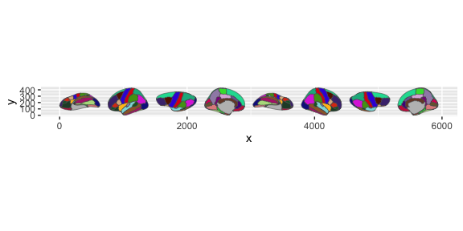

Default brain plot using geom_brain() with the dk atlas.

```r
ggplot() +
  geom_brain(atlas = dk(), show.legend = FALSE)
```

## Arranging views

Brain atlases have multiple views (lateral, medial) and hemispheres. `position_brain()` controls how they’re laid out, using formula syntax borrowed from `facet_grid()`:

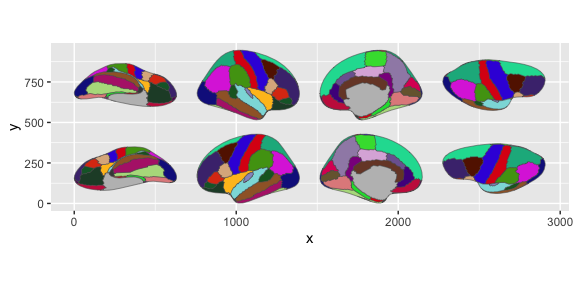

Brain views arranged using formula syntax in position_brain().

```r
ggplot() +
  geom_brain(
    atlas = dk(),
    position = position_brain(hemi ~ view),
    show.legend = FALSE
  )
```

Or reorder views with a character vector:

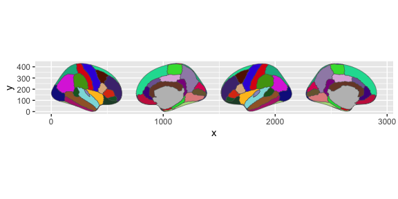

Brain views arranged using a character vector to specify order.

```r
ggplot() +
  geom_brain(
    atlas = dk(),
    position = position_brain(c(
      "right lateral",
      "right medial",
      "left lateral",
      "left medial"
    )),
    show.legend = FALSE
  )
```

See `vignette("positioning-views")` for the full set of layout options, including grid layouts for subcortical and tract atlases and per-view zoom.

## Showing only certain hemispheres or views

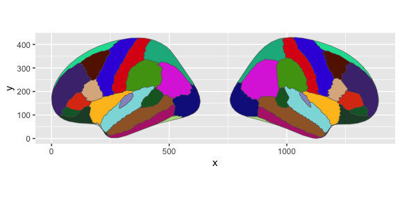

Brain plot showing only lateral views.

```r
ggplot() +
  geom_brain(atlas = dk(), view = "lateral", show.legend = FALSE)
```

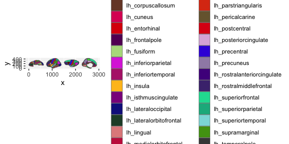

Brain plot showing only the left hemisphere.

```r
ggplot() +
  geom_brain(atlas = dk(), hemi = "left")
```

For subcortical atlases, views are slice identifiers. Check what’s available with `ggseg.formats::atlas_views()`:

```r
atlas_views(aseg())
```

```
#> [1] "axial_3"   "axial_4"   "axial_5"   "sagittal"  "axial_6"   "coronal_1"
#> [7] "coronal_2"
```

## Plotting your own data

Create a data frame with at least one column that matches the atlas (typically `region` or `label`). Pass it to `geom_brain()` through the `data` argument and it joins to the atlas automatically:

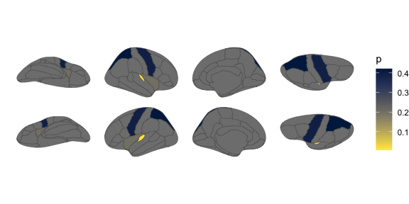

Brain plot coloured by external p-values using a viridis scale.

```r
library(dplyr)

some_data <- tibble(
  region = c(
    "transverse temporal",
    "insula",
    "precentral",
    "superior parietal"
  ),
  p = sample(seq(0, 0.5, 0.001), 4)
)

ggplot() +
  geom_brain(
    atlas = dk(),
    data = some_data,
    position = position_brain(hemi ~ view),
    aes(fill = p)
  ) +
  scale_fill_viridis_c(option = "cividis", direction = -1) +
  theme_void()
```

See `vignette("external-data")` for more on data preparation and matching.

## Faceting

ggplot2 faceting works as you’d expect. Group your data by the faceting variable and `geom_brain()` replicates the full atlas in each panel:

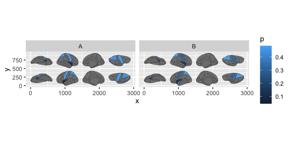

Brain plots faceted by group, each panel showing the full atlas.

```r
some_data <- tibble(
  region = rep(
    c(
      "transverse temporal",
      "insula",
      "precentral",
      "superior parietal"
    ),
    2
  ),
  p = sample(seq(0, 0.5, 0.001), 8),
  group = c(rep("A", 4), rep("B", 4))
)

ggplot() +
  geom_brain(
    atlas = dk(),
    data = group_by(some_data, group),
    position = position_brain(hemi ~ view),
    aes(fill = p)
  ) +
  facet_wrap(~group)
```

## Highlighting specific regions

To colour a few regions with their atlas colours, use two columns: one for the join (`region`) and one for the fill aesthetic:

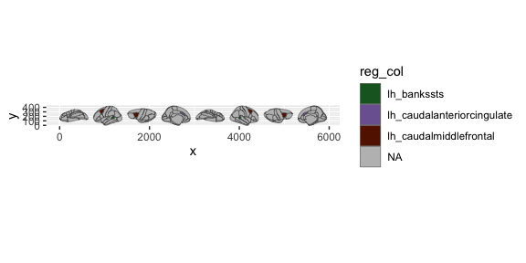

Highlighting selected regions using the atlas colour palette.

```r
data <- data.frame(
  region = atlas_regions(dk())[1:3],
  reg_col = atlas_labels(dk())[1:3]
)

palette <- atlas_palette(dk())[1:3]

ggplot() +
  geom_brain(atlas = dk(), data = data, aes(fill = reg_col)) +
  scale_fill_brain_manual(palette)
```

## Scales and themes

Atlas colour palettes are applied automatically by `geom_brain()`. For custom palettes, use `scale_fill_brain_manual()`.

Built-in themes strip axes and grids for cleaner figures:

```r
ggplot() +
  geom_brain(atlas = dk()) +
  theme_brain()
```

## Going further

For full control over the data before it reaches ggplot2 — adding region labels, layering other sf geoms, or using `geom_sf()` directly — see `vignette("geom-sf")`.

## Finding more atlases

ggseg ships with `dk()` (cortical), `aseg()` (subcortical), `suit()` (cerebellar flamap), and `tracula()` (white matter tracts). Many more are available through the [ggsegverse r-universe](https://ggsegverse.r-universe.dev):

```r
install.packages("ggsegYeo2011", repos = "https://ggsegverse.r-universe.dev")
```